# SDS 315 Homework 2

Avik Malladi

2024-01-28

##### arm7542

##### [Github Repository](https://github.com/avikMall/sds-315-homework-2)

## Problem 1: Beauty, or not, in the classroom

### Part A

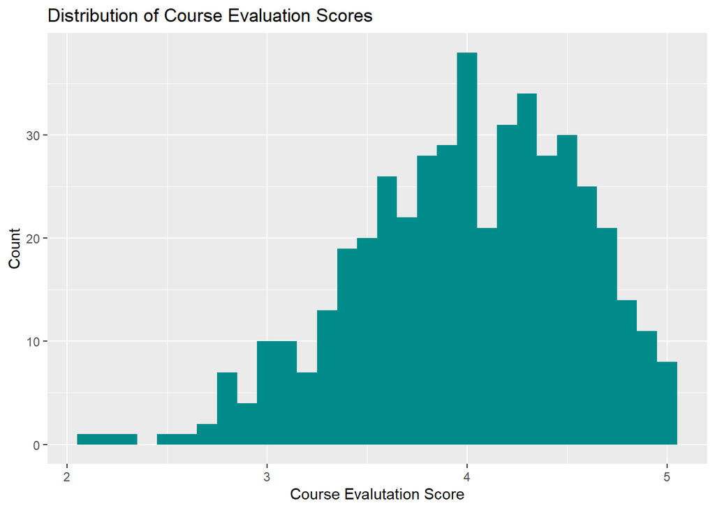

This histogram displays the overall distribution of course evaluation scores. The mean of the scores is 3.99.

### Part B

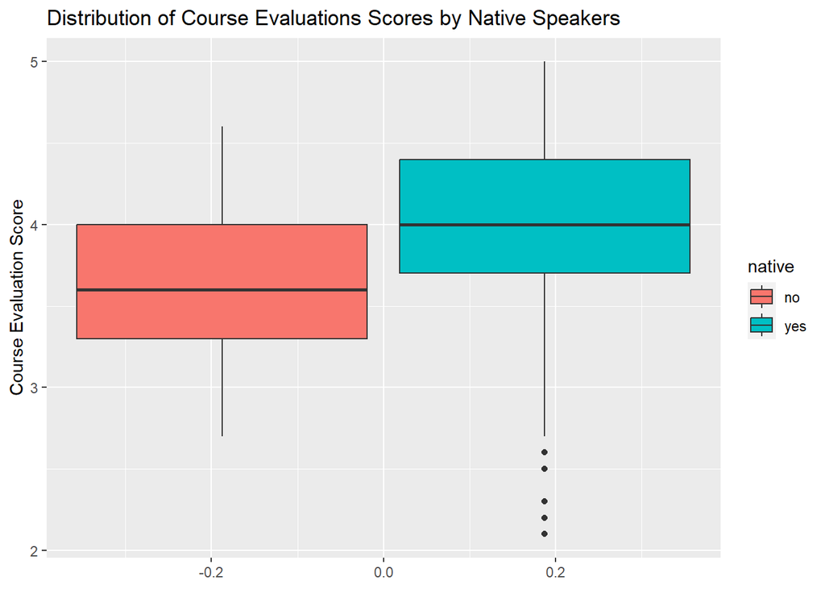

### Part C

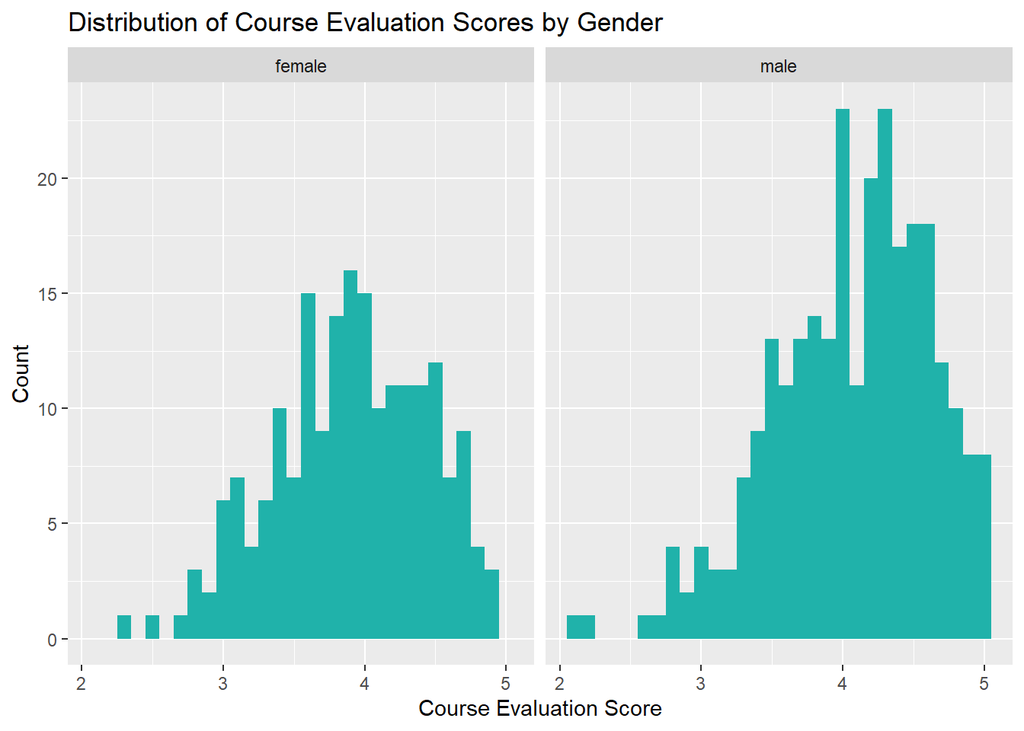

These two graphs show the distribution of the course evaluation scores split based on gender. There is more data collected for male professors and also a slightly higher mean evaluation score.

### Part D

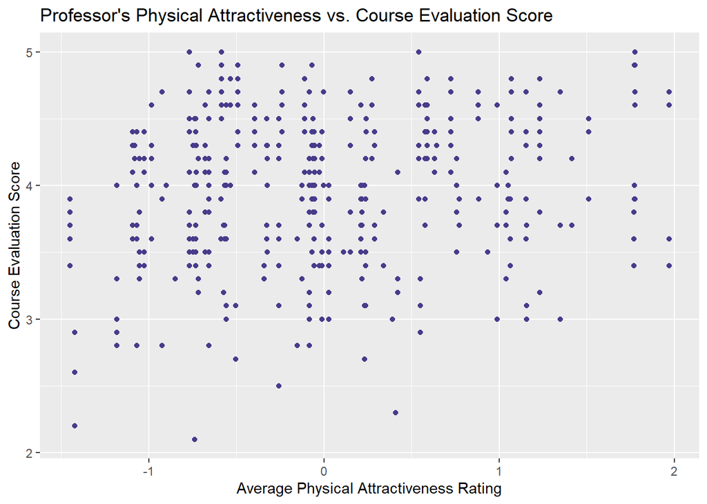

This dot plot shows the relationship between the professors average physical attractiveness rating and their average course evaluation score. The correlation coefficient between these to metrics is 0.19.

## Problem 2: Bike Sharing

### Part A

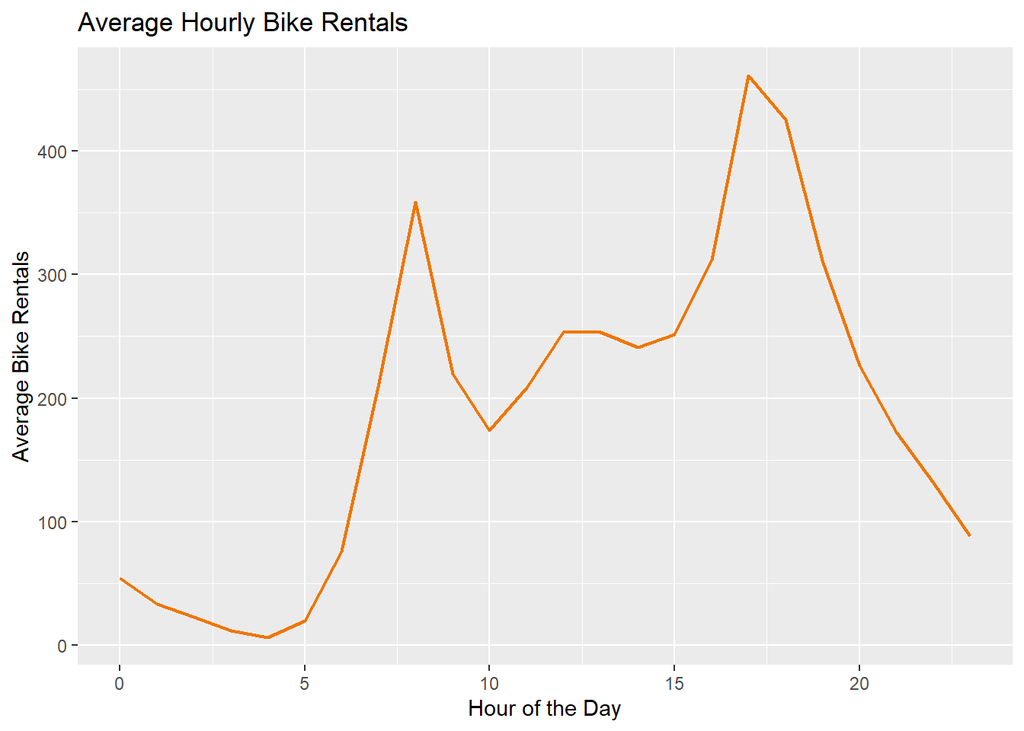

This line graph displays the average bike rentals throughout each hour of the day. From the graph we can see that the most active times of the day for bike rentals are hour 17 (5:00 PM) and hour 8 (8:00 AM).

### Part B

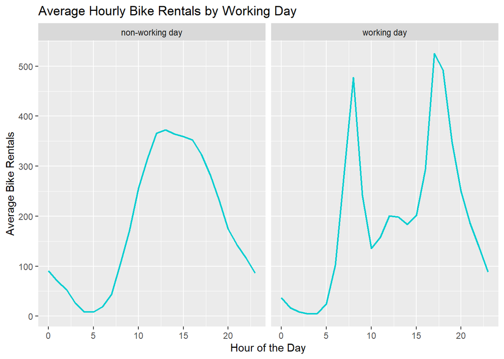

The faceted graph above displays the average bike rentals per hour on working days vs. non-working days (weekends and holidays). ‘0’ represents a non-working day, while ‘1’ represents a working day. We notice that working days have two significant peaks at 8:00 AM and 5:00 PM, while the non-working days have a fairly even distribution with a peak at around noon.

### Part C

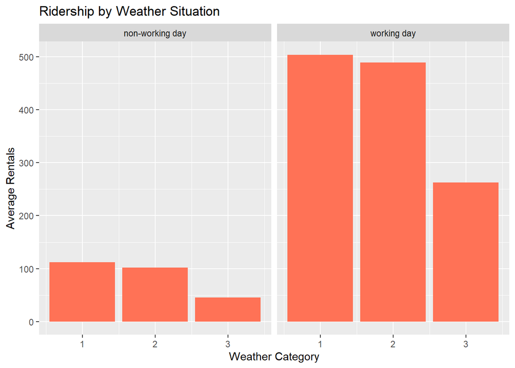

The graph above displays the average rentals based on different weather conditions for working days and non-working days. The weather conditions are defined as:

1: Clear, Few clouds, Partly cloudy, Partly cloudy 2: Mist + Cloudy, Mist + Broken clouds, Mist + Few clouds, Mist 3: Light Snow, Light Rain + Thunderstorm + Scattered clouds, Light Rain + Scattered clouds

We can see that in both working and non-working days, the weather condition 1 has the most ridership.

## Problem 3: Captial UT Metro Ridership

### Part A

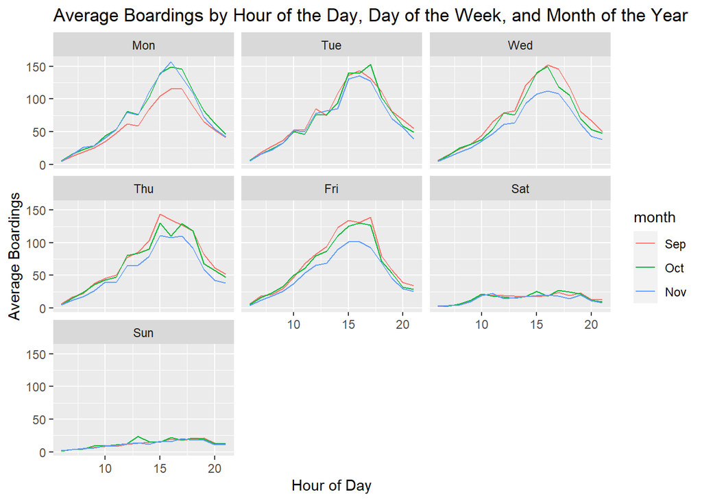

The graphs above display the average number of boardings separated by month, hour, and day of the week. Weekdays have similar peak times (4:00PM) while weekends do not have apparent peak times. Some significant metrics are the boarding in Mondays in September which appear lower possibly due to a holiday during that month. Similarly, Wednesday, Thursday, and Friday of November seem lower than the other lines as well possibly due to large amounts of people staying at home during Thanksgiving week.

### Part B

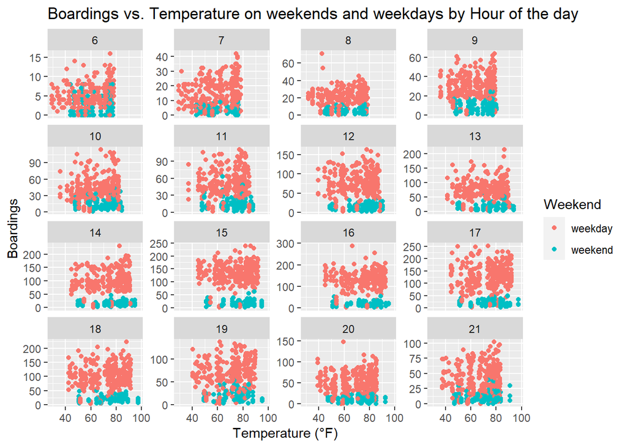

## Problem 4: Wrangling the Billboard Top 100

### Part A

Top 10 Most Popular Songs since 1958: Number of Weeks on Billboard Top 100

| performer | song | count |
| --- | --- | --- |
| Imagine Dragons | Radioactive | 87 |
| AWOLNATION | Sail | 79 |
| Jason Mraz | I’m Yours | 76 |
| The Weeknd | Blinding Lights | 76 |
| LeAnn Rimes | How Do I Live | 69 |
| LMFAO Featuring Lauren Bennett & GoonRock | Party Rock Anthem | 68 |
| OneRepublic | Counting Stars | 68 |
| Adele | Rolling In The Deep | 65 |
| Jewel | Foolish Games/You Were Meant For Me | 65 |
| Carrie Underwood | Before He Cheats | 64 |

This table displays the top 10 most popular songs since 1958 according to the Billboard Top 100. Provided is the Performer, Song name, and the number of weeks the song appeared in the Billboard top 100.

### Part B

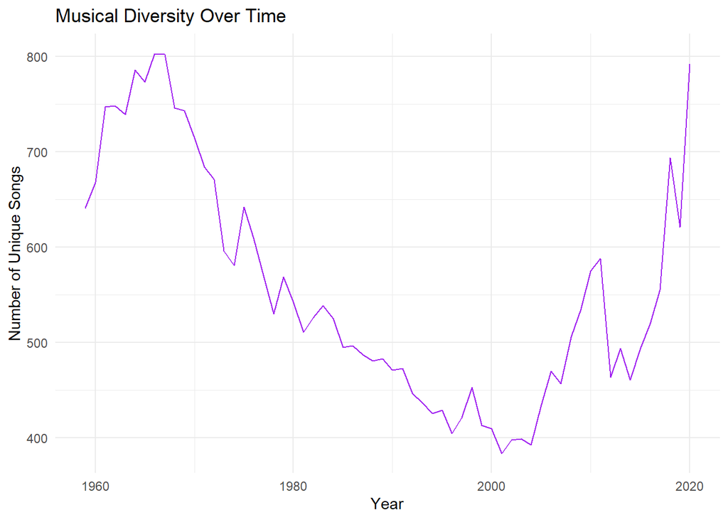

### Part C

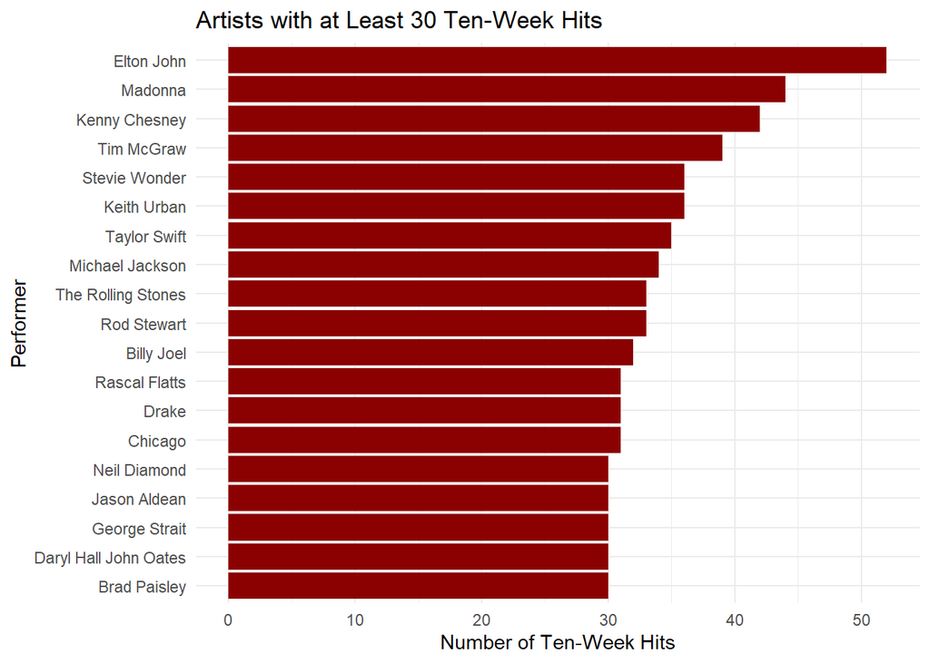

This graph shows the artists that had at least 30 songs that were on the billboard top 100 for ten weeks. Elton John tops the list with 52 ten-week hits.